# Exemplo: Estimação da área foliar

Alcinei Mistico Azevedo (ICA-UFMG)

2023-12-14

# Introdução

Obrigado por utilizar o pacote `ExpImage`. Este pacote foi desenvolvido a fim de facilitar o uso da análise de imagens na obtenção de várias informações sobre os objetos que elas contém. Para a utilização do pacote é indispensável a instalação do pacote `EBImage`. Geralmente, este pacote pode ser instalado ao executar os seguintes comandos:

`if (!requireNamespace("BiocManager", quietly = TRUE))`

`install.packages("BiocManager")`

`BiocManager::install("EBImage")`

Porém se houver problemas na instalação sugerimos que consulte mais opções de instalação no site: https://bioconductor.org/packages/release/bioc/html/EBImage.html

Para instalar o pacote ´ExpImage´ basta utilizar o seguinte comando:

`install.packages("ExpImage")`

Convidamos a todos os usuários do ExpImage que venha conhecer nossos materiais didáticos sobre este e outros pacotes nos seguintes links:

https://www.youtube.com/channel/UCDGyvLCJnv9RtTY1YMBMVNQ

https://www.expstat.com/

# Abrindo as imagens no R

## Ativação dos pacotes

Após a instalação dos pacotes é necessário fazer sua ativação

```r
library(EBImage)
library(ExpImage)
```

## Abrindo as imagens.

Para abrir as imagens pode-se inicialmente indicar a pasta de trabalho onde a imagem se encontra com a função `setwd`. E, posteriormente, abrir a imagem com a função `read_image`.

Neste caso, poderiam ser utilizados comandos como esses:

`#Apagar memoria do R`

`remove(list=ls())`

`#Indicar a pasta de trabalho`

`setwd("D:/Backup Pendrive/")`

`im=read_image("Imagem.jpeg",plot=TRUE)`

Neste exemplo utilizaremos imagens contidas no banco de dados do pacote. Vamos utilizar neste exemplo 4 imagens. Uma da imagem a ser avaliada e 3 de paletas de cores a serem utilizadas na segmentação.

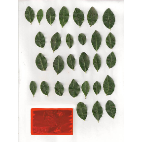

```r
#######################################################
#Abrir imagem das folhas
end1=example_image(3)
im=read_image(end1,plot=TRUE)
```

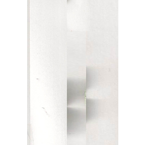

```r
#Abrir paleta de cores do fundo
end2=example_image(4)
fundo=read_image(end2,plot=TRUE)
```

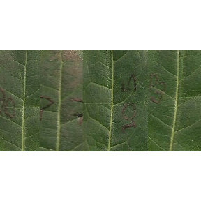

```r
#Abrir paleta de cores das folhas
end3=example_image(5)
folhas=read_image(end3,plot=TRUE)
```

[figure not shown]

```r
#Abrir paleta de cores referência
end4=example_image(6)
ref=read_image(end4,plot=TRUE)
```

# Segmentação

Para resolver este problema nós vamos fazer duas segmentações. A primeira para obter os pixels referente apenas às folhas. A segunda segmentação será feita para obter os pixels correspondente apenas ao objeto de referência.

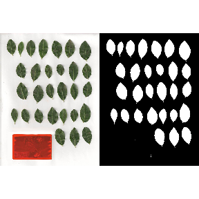

```r
#################################################################
#Segmentacao para separar as folhas do restante
folhas.seg=segmentation_logit(im,foreground=folhas,background=list(fundo,ref),sample=2000,fillHull=TRUE,plot=TRUE)
```

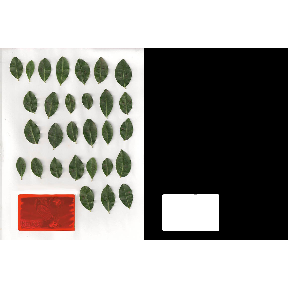

```r
#Segmentacao para separar o objeto de referencia do restante
ref.seg=segmentation_logit(im,foreground=ref,background=list(fundo,folhas),sample=2000,fillHull=TRUE,plot=TRUE)
```

# Estimação da área foliar

Agora que temos os pixels referentes apenas às folhas podemos estimar várias medidas com a função measure_image

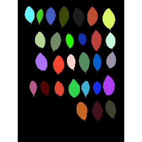

```r
medidas=measure_image(folhas.seg,noise = 1000)
```

```r
#numero de objetos e medias
medidas
```

```
#> $ObjectNumber
#> [1] 29
#>
#> $measures
#>          x       y area perimeter radius.mean radius.sd radius.min radius.max
#> 1  251.915  88.297 4532       253      39.730    10.697     24.640     61.968
#> 2   64.913  79.666 3544       214      34.668     7.432     25.426     50.664
#> 3  408.136  89.978 4405       234      38.106     8.094     26.424     55.183
#> 4  179.859  86.098 3675       213      34.792     7.656     25.245     51.145
#> 5  332.517  91.788 4534       240      38.970     7.715     29.653     57.018
#> 6  498.538 102.647 5594       260      43.148     8.344     33.374     60.668
#> 7  120.783  85.113 1961       183      27.424     8.970     14.854     45.148
#> 8  430.207 221.427 4468       249      39.487    10.426     26.533     62.175
#> 9  122.397 219.572 3768       211      34.899     6.115     25.543     47.921
#> 10 207.348 227.912 4263       241      38.353     9.149     26.619     57.122
```

[output cut: 52 more lines]

Com o comando acima temos várias medidas de áreas em pixels. Logo, é legal converter essa medida para cm² a partir do objeto de referência. Sabendo a área do objeto de referência podemos fazer a conversão com da seguinte forma:

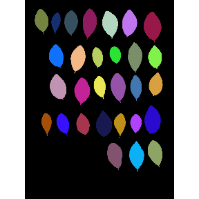

```r
#Convertendo a area dos objetos para cm2

#Identificando a area do objeto de referência (maior area)
# A area conhecida do objeto de referência tem 8.5 x 5.5 cm
#e sua areasegmentada esta no objeto ref.seg

medidasref=measure_image(img = folhas.seg,noise =1000,id=ref.seg,length =8.5,width =5.5 )
```

```r
#numero de objetos e medias
medidasref
```

```
#> $ObjectNumber
#> [1] 29
#>
#> $measures
#>          x       y     area perimeter radius.mean radius.sd radius.min
#> 1  251.915  88.297 6.181503  355.7701    55.86856 15.042184   34.64891
#> 2   64.913  79.666 4.833902  300.9280    48.75034 10.450922   35.75419
#> 3  408.136  89.978 6.008279  329.0522    53.58488 11.381830   37.15758
#> 4  179.859  86.098 5.012582  299.5218    48.92471 10.765912   35.49967
#> 5  332.517  91.788 6.184230  337.4894    54.79984 10.848878   41.69822
#> 6  498.538 102.647 7.630036  365.6135    60.67497 11.733381   46.93071
#> 7  120.783  85.113 2.674741  257.3357    38.56379 12.613666   20.88778
#> 8  430.207 221.427 6.094209  350.1452    55.52685 14.661102   37.31086
#> 9  122.397 219.572 5.139431  296.7094    49.07518  8.598949   35.91872
#> 10 207.348 227.912 5.814595  338.8956    53.93221 12.865377   37.43179
```

[output cut: 52 more lines]

Para a melhor visualização dos resultados, podemos sobrepor a área das folhas sobre a imagem com o seguinte comando:

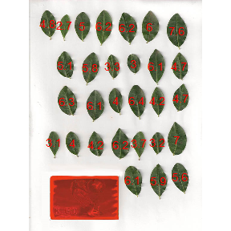

```r
#Plotar resultados das areas em pixel e salvar em imagem jpg
plot_meansures(im,medidasref$measures[,1],coordy=medidasref$measures[,2],text=round(medidasref$measures[,3],1),col="red",
               cex = 0.9 ,plot=TRUE)
```